# Supplementary Information S2 : Characterisation of root growth dynamics

**Our objective is to differentiate between mature and growing (apex) root zones based on temporal variations in surface area**. We operate on the assumption that root elongation and expansion occur dynamically during an initial active phase, followed by a period of physiological stabilization or growth deceleration.

By quantifying surface area increments ($\Delta$) across increasing time lags, we can identify the inflection point where the rate of new surface accumulation begins to decelerate. This threshold defines the temporal window used to distinguish “newly emerged” functional segments from the established root network.

## Surface area normalization

To convert root occupancy from digital units (pixels) to physical metric units ($cm^2$), we account for the scanner resolution (1200 dpi). The conversion factor is derived from the linear resolution: $1200 \text{ dpi} / 2.54 \text{ cm/in} \approx 472.44 \text{ pixels/cm}$.

The surface area in $cm^2$ is calculated as:

$$Surface (cm^2) = Pixels / (472.44)^2$$

## Visualization of root surface trends

The following plot displays the evolution of total root surface area across the curated image bank, faceted by scanner unit :

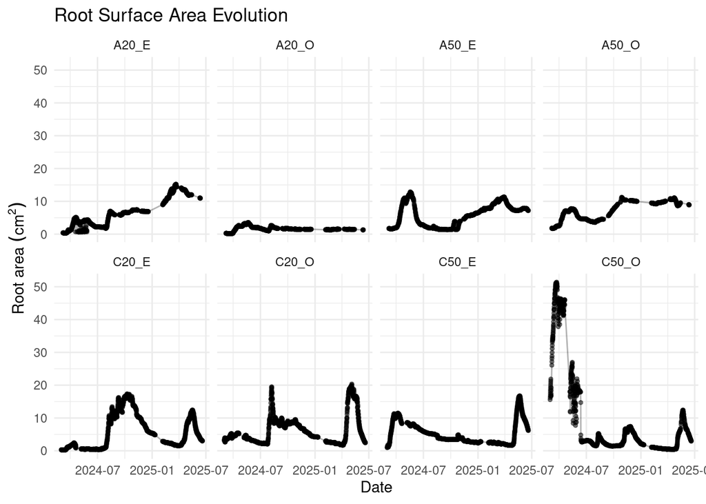

## Quantification of apex surfaces according to time lags

The difference in surface area between two successive observations represents newly emerged root tissue (the apices). **We analyzed the distribution of surface increments (**$\Delta cm^2$**) across intervals ranging from 6 to 720 hours (30 days)**. We applied an Interquartile Range (IQR) filter to remove extreme outliers in surface density that could skew growth estimates. Only positive increments are retained to represent growth; negative deltas—resulting from experimental noise or root decomposition—are normalized to zero.

The average apex areas as a function of time step are shown, along with their variability (standard deviation). An initial average is calculated by scanner, then the values are aggregated:

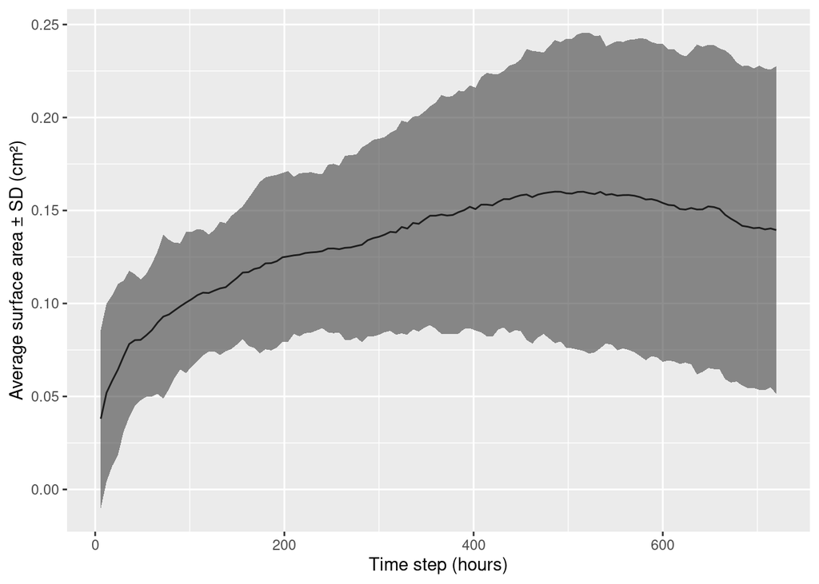

## Statistical Modeling and Threshold Detection

```
thresholds : 9 days
```

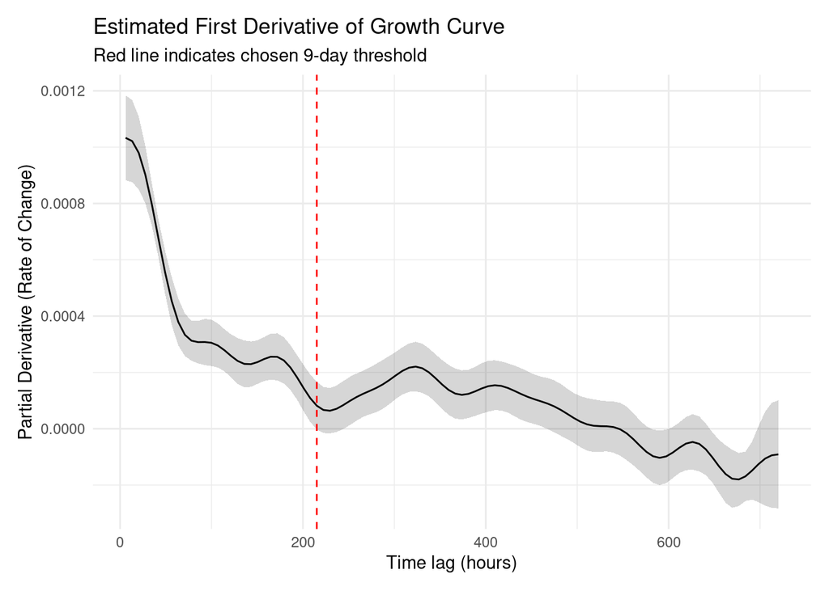

**This 9-day interval serves as a functional boundary to distinguish highly active apical zones from more stable, mature root segments.**